# Lab III: Credit Card Marketing Campaign

Zifeng Zhao

week 06 session 01

In this lab, we will build logistic regression, GAM and neural networks for targeted advertising in the credit card marketing campaign.

## 1. Read in Data and Data Partition

Let’s first read in the data from `CreditCard_Ads.csv` and store it in `R` object `total_data`.

```r
rm(list=ls())
total_data <- read.csv("./CreditCard_Ads.csv", header=T, stringsAsFactors=T)
```

**Exercise 1** In total, we have `10570` observations, which is a decent sample size. Thus, let’s partition the data in `total_data` into training **(60%)** and test data **(40%)** and store them as `R` objects `train_data` and `test_data` respectively. Use random seed **`set.seed(7)`**!

```r
set.seed(7)

total_obs <- dim(total_data)[1]

train_data_indices <- sample(1:total_obs, 0.6*total_obs)
train_data <- total_data[train_data_indices,]
test_data <- total_data[-train_data_indices,]
```

```r
str(train_data)
```

```
## 'data.frame':    6342 obs. of  11 variables:
##  $ Age     : int  33 27 33 49 33 48 35 27 59 44 ...
##  $ Default : Factor w/ 2 levels "no","unknown": 1 1 1 2 1 1 1 1 2 1 ...
##  $ Housing : Factor w/ 2 levels "no","yes": 2 1 1 1 1 1 2 1 1 1 ...
##  $ Loan    : Factor w/ 2 levels "no","yes": 1 2 2 1 2 1 1 1 1 1 ...
##  $ Contact : Factor w/ 2 levels "cellular","telephone": 1 1 2 2 2 1 1 1 2 1 ...
##  $ Previous: int  1 7 2 1 2 7 1 1 2 1 ...
##  $ Poutcome: Factor w/ 3 levels "failure","nonexistent",..: 2 2 1 2 2 2 2 1 2 1 ...
##  $ EVR     : num  -1.8 -3.4 -1.8 1.1 1.1 -0.1 -0.1 -1.8 1.1 -3.4 ...
##  $ CPI     : num  92.9 92.6 93.4 94 94 ...
##  $ CCI     : num  -46.2 -30.1 -34.8 -36.4 -36.4 -42 -42 -46.2 -36.4 -26.9 ...
##  $ Y       : Factor w/ 2 levels "no","yes": 2 1 1 1 1 1 1 1 1 1 ...
```

```r
str(test_data)
```

```
## 'data.frame':    4228 obs. of  11 variables:
##  $ Age     : int  36 49 34 33 36 33 33 50 44 46 ...
##  $ Default : Factor w/ 2 levels "no","unknown": 2 2 1 1 1 1 1 1 1 2 ...
##  $ Housing : Factor w/ 2 levels "no","yes": 1 2 1 2 2 2 2 2 1 1 ...
##  $ Loan    : Factor w/ 2 levels "no","yes": 1 1 1 1 1 1 1 1 1 1 ...
##  $ Contact : Factor w/ 2 levels "cellular","telephone": 1 1 2 1 2 2 2 1 1 2 ...
##  $ Previous: int  1 1 1 1 2 1 3 3 1 2 ...
##  $ Poutcome: Factor w/ 3 levels "failure","nonexistent",..: 2 2 2 3 2 2 2 2 1 2 ...
##  $ EVR     : num  -1.8 1.4 -1.7 -2.9 1.1 1.4 1.1 -1.8 -0.1 -1.8 ...
##  $ CPI     : num  92.9 93.4 94 92.2 94 ...
##  $ CCI     : num  -46.2 -36.1 -38.3 -31.4 -36.4 -41.8 -36.4 -47.1 -42 -46.2 ...
##  $ Y       : Factor w/ 2 levels "no","yes": 1 1 1 1 1 1 1 1 1 1 ...
```

**Exercise 1.1** What is the conversion rate in the current dataset?

```r
dim(total_data[total_data$Y=='yes',])[1] / dim(total_data)[1] * 100
```

```
## [1] 11.31504
```

## 2. Logistic Regression

**Exercise 2** Estimate a logistic regression model for the dependent variable `Y` with all **10** predictors `Age+Default+Housing+Loan+Contact+Previous+Poutcome+EVR+CPI+CCI` based on the **training** data using the function `glm()` and name it `lm_full`. Note that we need to specify the `family` argument in `glm()` as `binomial`.

```r
lm_full <- glm(Y ~ Age+Default+Housing+Loan+Contact+Previous+Poutcome+EVR+CPI+CCI,
               family = 'binomial', data = train_data)
```

```r
summary(lm_full)
```

```
##
## Call:
## glm(formula = Y ~ Age + Default + Housing + Loan + Contact +
##     Previous + Poutcome + EVR + CPI + CCI, family = "binomial",
##     data = train_data)
##
## Deviance Residuals:
##     Min       1Q   Median       3Q      Max
## -1.7305  -0.4172  -0.3314  -0.2916   3.0981
##
## Coefficients:
##                       Estimate Std. Error z value Pr(>|z|)
## (Intercept)         -1.149e+02  1.082e+01 -10.617  < 2e-16 ***
## Age                 -1.969e-03  3.818e-03  -0.516  0.60593
## Defaultunknown      -1.806e-01  1.362e-01  -1.326  0.18483
## Housingyes          -7.642e-04  8.890e-02  -0.009  0.99314
## Loanyes             -6.049e-03  1.249e-01  -0.048  0.96137
## Contacttelephone    -9.521e-01  1.321e-01  -7.209 5.65e-13 ***
## Previous            -7.912e-02  2.564e-02  -3.085  0.00203 **
## Poutcomenonexistent  7.344e-01  1.438e-01   5.108 3.26e-07 ***
## Poutcomesuccess      1.870e+00  1.982e-01   9.436  < 2e-16 ***
## EVR                 -7.447e-01  4.358e-02 -17.087  < 2e-16 ***
## CPI                  1.224e+00  1.168e-01  10.474  < 2e-16 ***
## CCI                  4.908e-02  8.558e-03   5.736 9.72e-09 ***
## ---
## Signif. codes:  0 '***' 0.001 '**' 0.01 '*' 0.05 '.' 0.1 ' ' 1
##
## (Dispersion parameter for binomial family taken to be 1)
##
##     Null deviance: 4475.6  on 6341  degrees of freedom
## Residual deviance: 3640.7  on 6330  degrees of freedom
## AIC: 3664.7
##
## Number of Fisher Scoring iterations: 6
```

**Exercise 3** Does higher EVR make the conversion more difficult? How about higher CCI? Higher EVR makes conversion more difficult. Higher CCI makes conversion more easy.

### 2.1 Backward selection

**Exercise 4** It seems that some of the predictors are not statistically significant. First, determine the number of observations in the training data. Second, let’s do a backward selection via BIC using the `step()` function and store the final selected model as `lm_bwd`. Make sure you use the **correct** number for the argument `k` in the `step()` function.

```r
lm_bwd <- step(lm_full, direction = 'backward', k = log(dim(train_data)[1]))
```

```
## Start:  AIC=3745.74
## Y ~ Age + Default + Housing + Loan + Contact + Previous + Poutcome +
##     EVR + CPI + CCI
##
##            Df Deviance    AIC
## - Housing   1   3640.7 3737.0
## - Loan      1   3640.7 3737.0
## - Age       1   3641.0 3737.3
## - Default   1   3642.5 3738.8
## <none>          3640.7 3745.7
## - Previous  1   3652.1 3748.4
## - CCI       1   3673.9 3770.2
## - Contact   1   3695.7 3792.0
## - Poutcome  2   3736.0 3823.6
## - CPI       1   3747.1 3843.4
## - EVR       1   3939.9 4036.2
##
## Step:  AIC=3736.99
## Y ~ Age + Default + Loan + Contact + Previous + Poutcome + EVR +
##     CPI + CCI
##
##            Df Deviance    AIC
## - Loan      1   3640.7 3728.2
## - Age       1   3641.0 3728.5
## - Default   1   3642.5 3730.0
## <none>          3640.7 3737.0
## - Previous  1   3652.1 3739.7
## - CCI       1   3673.9 3761.4
## - Contact   1   3695.8 3783.3
## - Poutcome  2   3736.1 3814.9
## - CPI       1   3747.2 3834.8
## - EVR       1   3940.0 4027.6
##
## Step:  AIC=3728.24
## Y ~ Age + Default + Contact + Previous + Poutcome + EVR + CPI +
##     CCI
##
##            Df Deviance    AIC
## - Age       1   3641.0 3719.7
## - Default   1   3642.5 3721.3
```

[output cut: 17 more lines]

```
## - Poutcome  2   3736.2 3797.5
## - CPI       1   3747.5 3817.5
## - EVR       1   3941.1 4011.1
##
## Step:  AIC=3713.06
## Y ~ Contact + Previous + Poutcome + EVR + CPI + CCI
##
##            Df Deviance    AIC
## <none>          3643.0 3713.1
## - Previous  1   3654.4 3715.7
## - CCI       1   3677.0 3738.3
## - Contact   1   3699.3 3760.6
## - Poutcome  2   3738.8 3791.3
## - CPI       1   3751.3 3812.6
## - EVR       1   3957.9 4019.2
```

**Exercise 5** Which variable is removed during the backward selection? Removed Variables: Housing, Loan, Age, Default

## 3. Generalized Additive Model

**Exercise 6** Estimate a GAM model with all **10** predictors to capture potential nonlinear relationship. We specify splines with degree-of-freedom=4 for all numerical predictors, including `Age`, `Previous`, `EVR`, `CPI` and `CCI`, and we store the model in `gam1`. Note that we need to specify the `family` argument in `gam()` as `binomial`. We can use `plot()` function to visualize the estimated coefficients and splines for each predictor. Note that we can still interpret the estimated model `gam1` due to the additivity of GAM.

```r
library(gam)
gam1 <- gam(Y ~
              s(Age,df=4)
            +Default
            +Housing
            +Loan
            +Contact
            +s(Previous,df=4)
            +Poutcome
            +s(EVR,df=4)
            +s(CPI,df=4)
            +s(CCI,df=4),
            family = 'binomial',
            data = train_data)
```

```r
summary(gam1)
```

```
##
## Call: gam(formula = Y ~ s(Age, df = 4) + Default + Housing + Loan +
##     Contact + s(Previous, df = 4) + Poutcome + s(EVR, df = 4) +
##     s(CPI, df = 4) + s(CCI, df = 4), family = "binomial", data = train_data)
## Deviance Residuals:
##     Min      1Q  Median      3Q     Max
## -1.9078 -0.3923 -0.3392 -0.2650  2.8927
##
## (Dispersion Parameter for binomial family taken to be 1)
##
##     Null Deviance: 4475.638 on 6341 degrees of freedom
## Residual Deviance: 3565.02 on 6315 degrees of freedom
## AIC: 3619.02
##
## Number of Local Scoring Iterations: NA
##
## Anova for Parametric Effects
##                       Df Sum Sq Mean Sq  F value    Pr(>F)
## s(Age, df = 4)         1    4.9   4.938   4.9144   0.02667 *
## Default                1   64.8  64.793  64.4834 1.152e-15 ***
## Housing                1    0.4   0.430   0.4278   0.51309
## Loan                   1    0.2   0.180   0.1787   0.67255
## Contact                1  103.8 103.845 103.3487 < 2.2e-16 ***
## s(Previous, df = 4)    1   25.5  25.515  25.3934 4.805e-07 ***
## Poutcome               2  206.9 103.439 102.9451 < 2.2e-16 ***
## s(EVR, df = 4)         1  281.2 281.191 279.8476 < 2.2e-16 ***
## s(CPI, df = 4)         1  100.9 100.893 100.4113 < 2.2e-16 ***
## s(CCI, df = 4)         1    4.3   4.296   4.2759   0.03870 *
## Residuals           6315 6345.3   1.005
## ---
## Signif. codes:  0 '***' 0.001 '**' 0.01 '*' 0.05 '.' 0.1 ' ' 1
##
## Anova for Nonparametric Effects
##                     Npar Df Npar Chisq    P(Chi)
## (Intercept)
## s(Age, df = 4)            3      5.061   0.16739
## Default
## Housing
## Loan
## Contact
## s(Previous, df = 4)       3      6.447   0.09178 .
## Poutcome
## s(EVR, df = 4)            3      7.678   0.05315 .
## s(CPI, df = 4)            3     26.032 9.390e-06 ***
## s(CCI, df = 4)            3     37.760 3.178e-08 ***
## ---
## Signif. codes:  0 '***' 0.001 '**' 0.01 '*' 0.05 '.' 0.1 ' ' 1
```

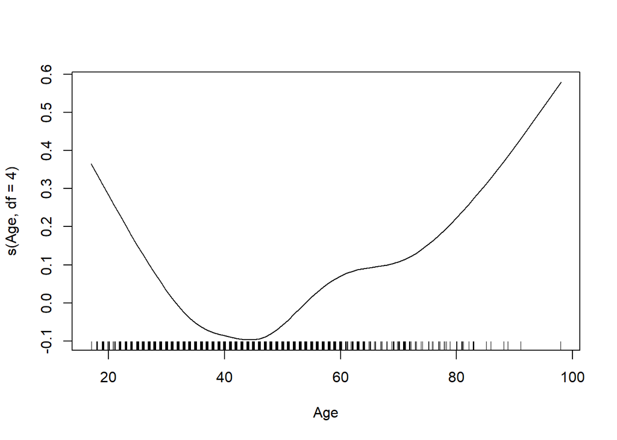

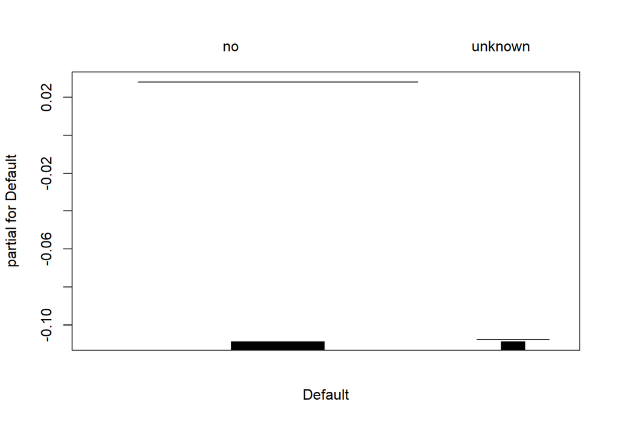

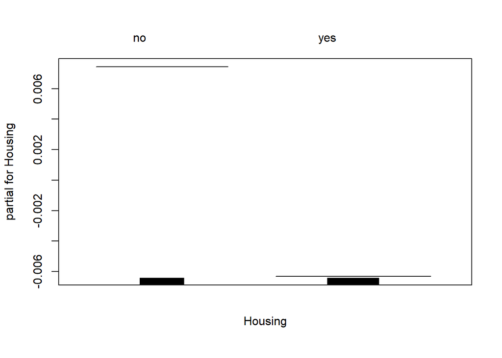

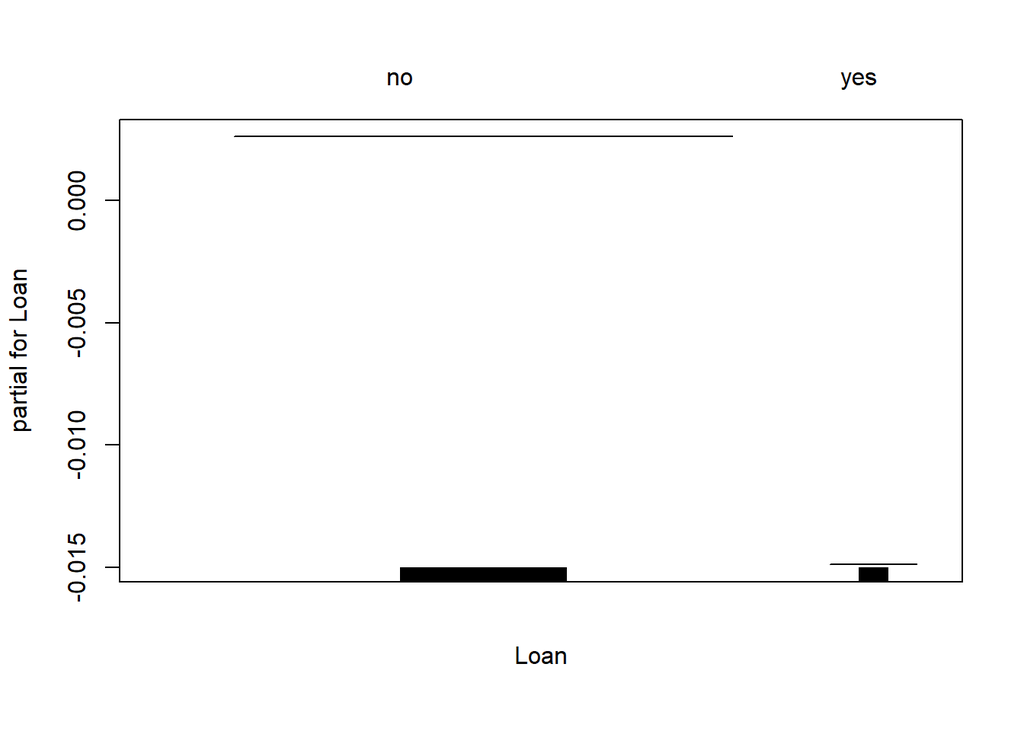

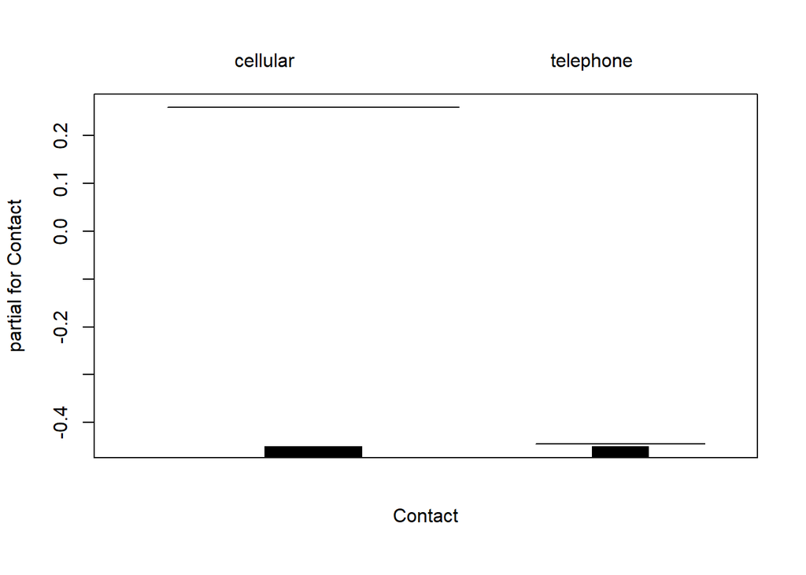

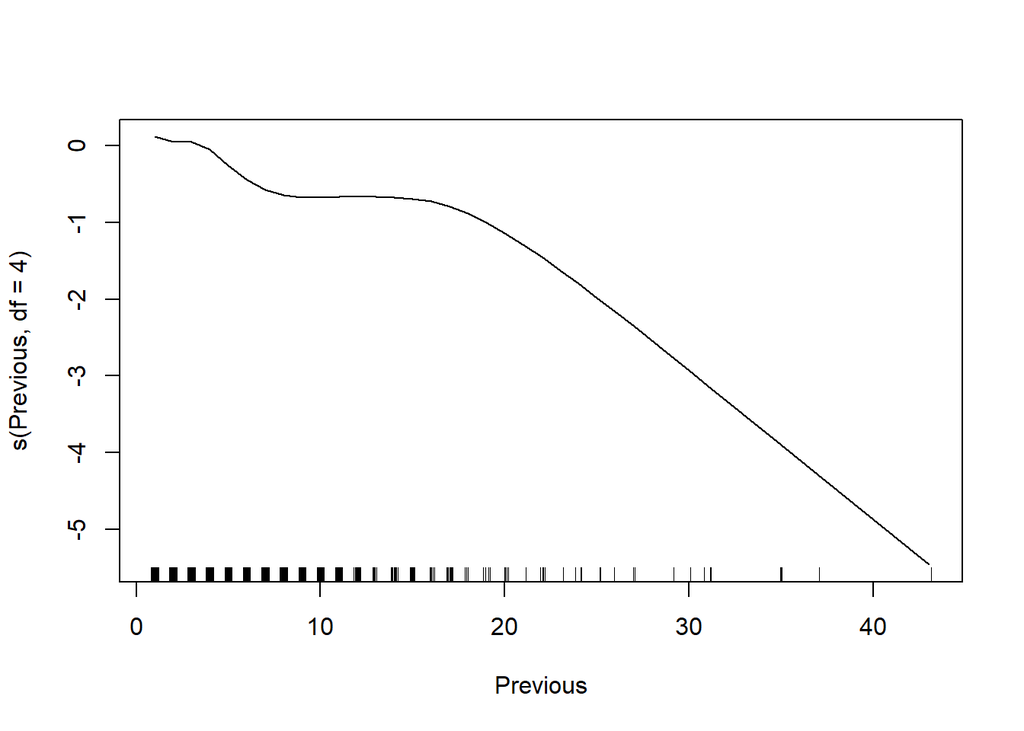

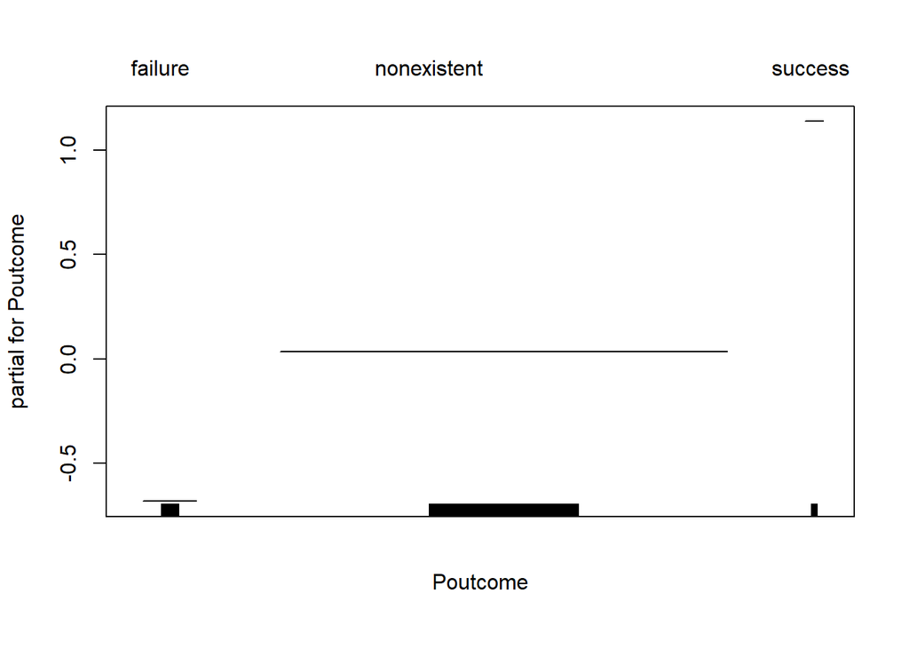

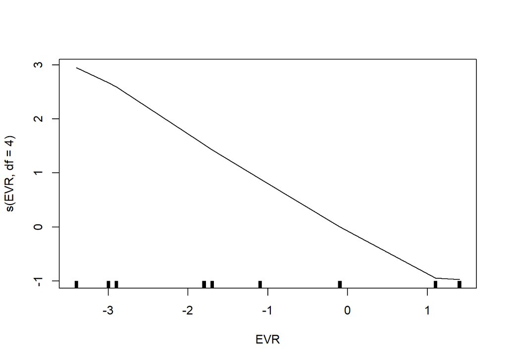

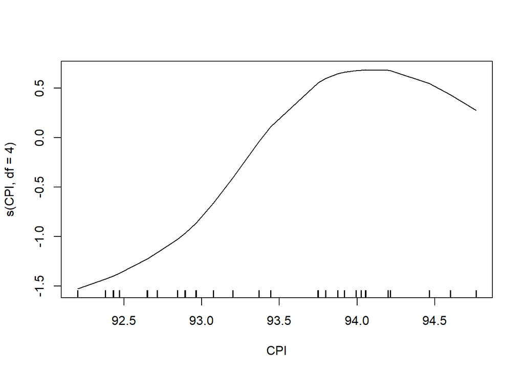

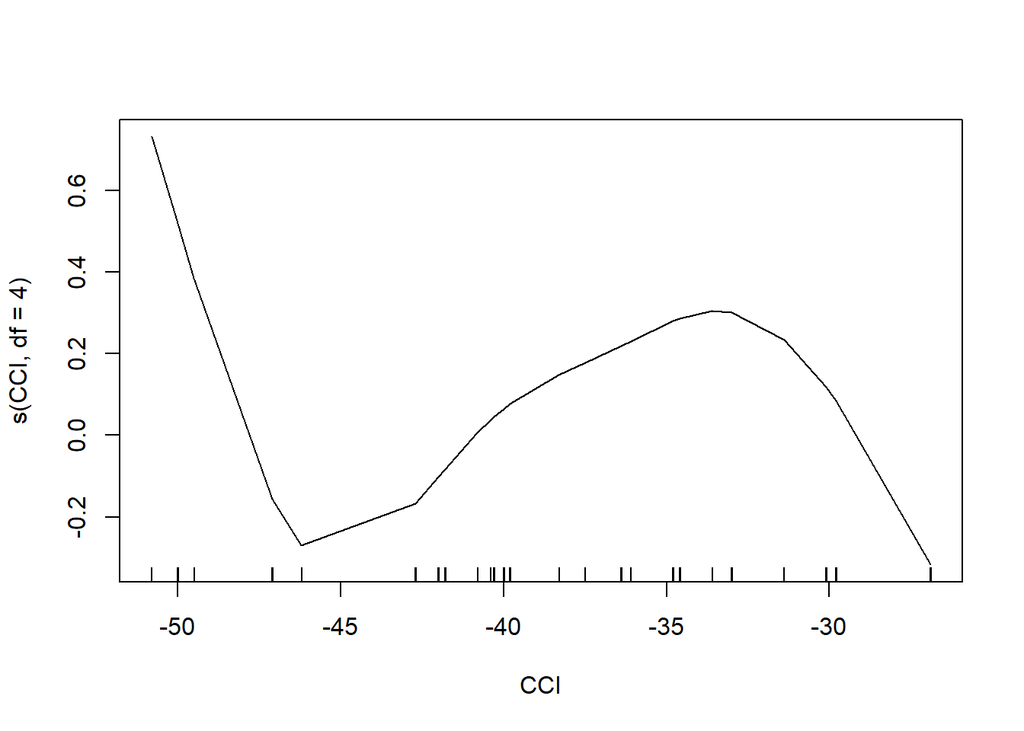

```r
plot(gam1)
```

## 4. Neural Networks

Estimate an NN with all **10** predictors, name it `nn1`. For the architecture of NN, let’s use one hidden layer with 4 hidden units.

**Exercise 7** Let’s first generate the **training dataset** that are needed for the estimation of NN using the function `model.matrix()` and store it in `x_train_nn`. In addition, use the `scale()` function to standardize the predictors by centering with mean and scaling with sd. In addition, combine the dependent variable `Y` with the standardized predictors stored in `x_train_nn`. Make sure to rename the colnames of `x_train_nn` correctly for `Y`!

```r
# generate a data frame with categorical predictors being represented as dummy variables
x_train_nn <- model.matrix(~Age+Default+Housing+Loan+Contact+Previous+Poutcome+EVR+CPI+CCI, data=train_data)[,-1]

# standardization
x_mean <- apply(x_train_nn, 2, mean)
x_sd <- apply(x_train_nn, 2, sd)
x_train_nn <- scale(x_train_nn, center=x_mean, scale=x_sd)

# combine with dependent variable Log_price
x_train_nn <- cbind.data.frame(train_data$Y, x_train_nn)
colnames(x_train_nn)[1] <- 'Y'
```

**Exercise 8** Let’s further generate the **test dataset** that are needed for the out-of-sample prediction evaluation of NN using the function `model.matrix()` and store it in `x_test_nn`. Use the `scale()` function to standardize the predictors by centering with mean and scaling with sd as in Exercise 8.

```r
# generate and standardize the data frame for the test data as well
x_test_nn <- model.matrix(~Age+Default+Housing+Loan+Contact+Previous+Poutcome+EVR+CPI+CCI, data=test_data)[,-1]

# standardization
x_test_nn <- scale(x_test_nn, center=x_mean, scale=x_sd)
```

**Exercise 9** Let’s fit an NN that has one hidden layer with 4 hidden units. Make sure to use random seed **`set.seed(7)`**! Don’t forget to use **`Y=='yes'`** to convert the categorical variable `Y` to a dummy 0-1 coding. Note that we need to specify the `linear.output` argument in `neuralnet()` as `False`.

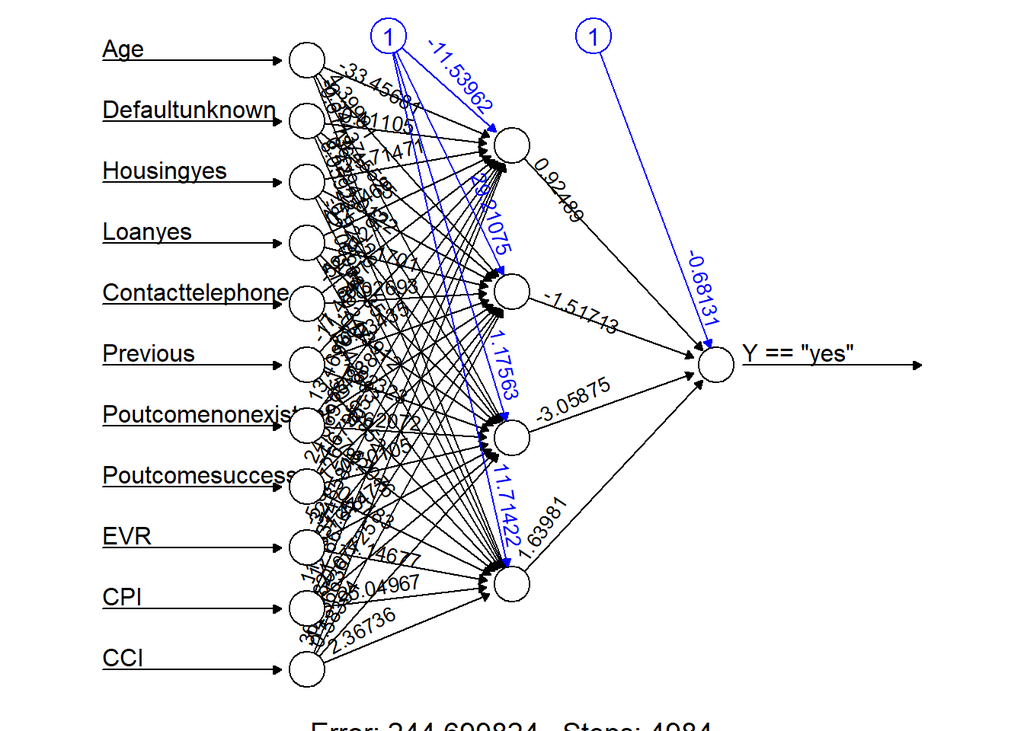

```r
library(neuralnet)
set.seed(7)
nn1 <- neuralnet(Y=='yes'~., data=x_train_nn, hidden=c(4), linear.output=F)
plot(nn1, rep='best')
```